# Lecture 7.1. Data visualization - Intro

Carlos Ramirez Alvarez

9/7/2019

# Base plottings

Base plottings refers to build in functions for data visualization. They are specially useful for exploratory data analysis.

Let’s load the Moignard data.

```r
path <- 'https://raw.githubusercontent.com/caramirezal/dataScience/master/data/NIHMS53736-supplement-9.csv'
transcripts <- read.csv(path, header = TRUE)
```

## plot() - Plotting points.

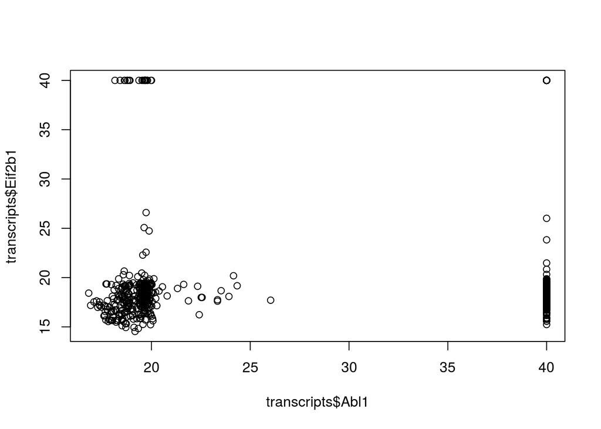

```r
plot(transcripts$Abl1, transcripts$Eif2b1)
```

## with() - Makes columns available by its name.

Function with() avoids the necessity of writting the name of the data frame many times and makes the code more readable.

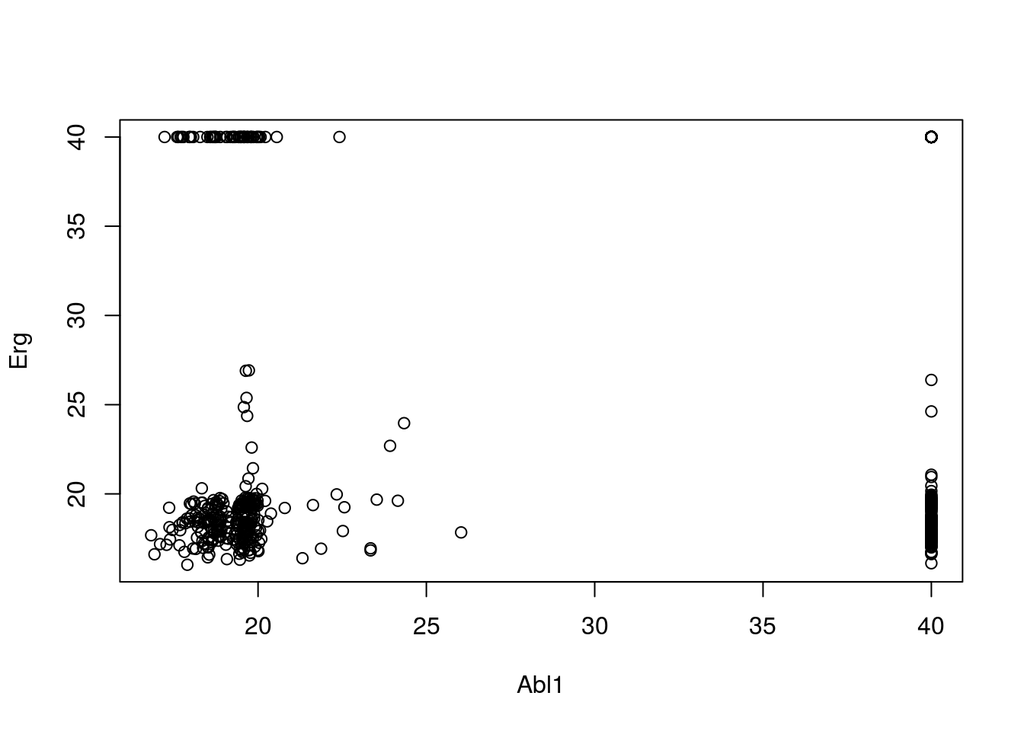

```r
with(transcripts,
     plot(Abl1, Erg)
)
```

## hist() - Histograms.

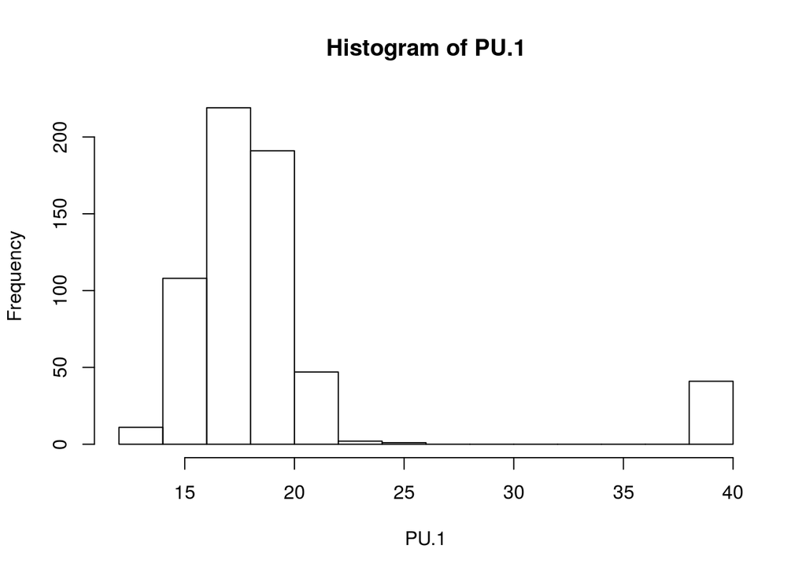

```r
with(transcripts,
     hist(PU.1)
)
```

## Multiple plots

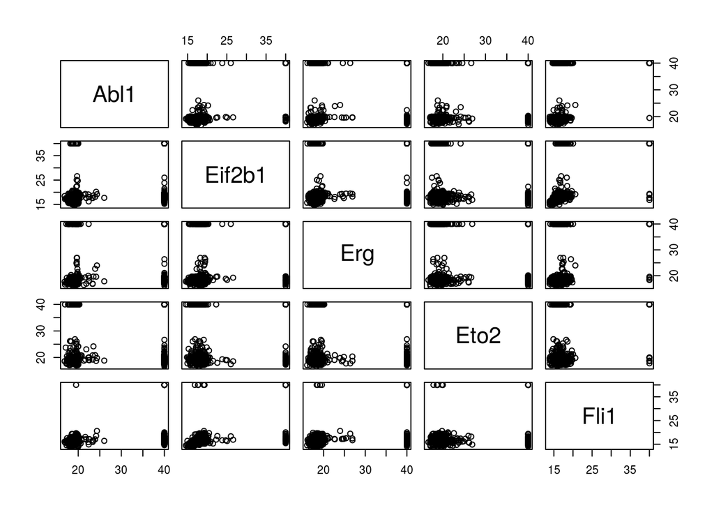

```r
library(dplyr)
## selecting a set of genes in the data frame
selectedTranscripts <- select(transcripts, Abl1:Fli1)
## plotting
plot(selectedTranscripts)
```

## heatmap()

Heatmaps are graphical representations for matrices where color codes in the cells of the heatmap are proportional to the entries in the matrix.

Heatmaps can be rearranged according to the similarity of the rows and columns in the matrix.

heatmap() only works with numerical matrices.

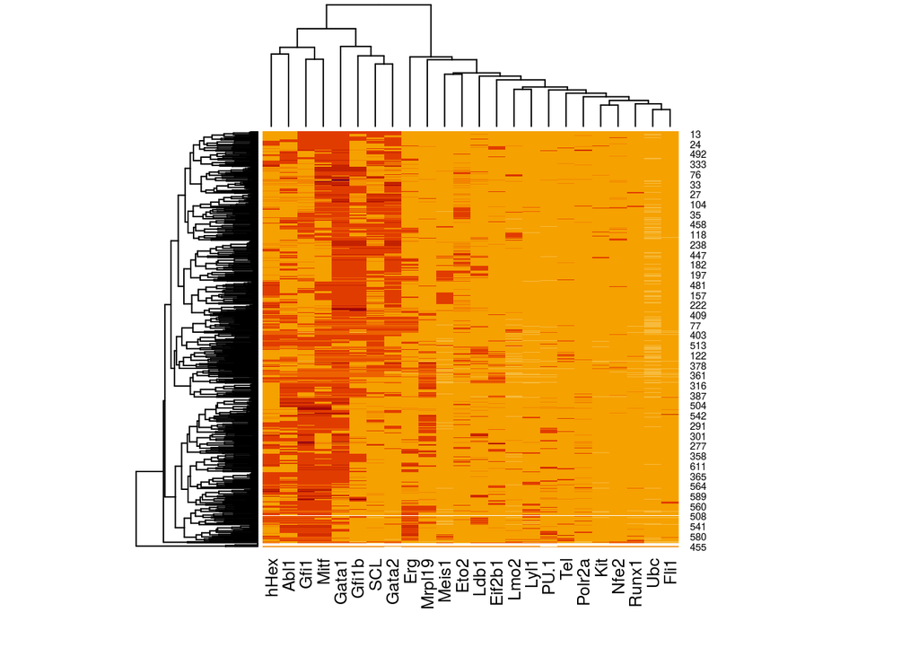

```r
## Processing data
## selecting numerical data
transcripts.num <- select(transcripts, Abl1:Ubc)
## transforming dataframe to matrix
transcripts.m <- as.matrix(transcripts.num)

heatmap(transcripts.m)
```

## Adding colors and annotations

Base plots have many parameters in order to improve visualizations. Here, we give some example parameters.

- col - color of the points, lines, bar, etc…
- pch - type of the point. Find a list of point types [here](http://www.endmemo.com/program/R/pchsymbols.php).
- cex - size of the point.
- main - plot tittle.
- xlab - x axis label.
- ylab - y axis label.

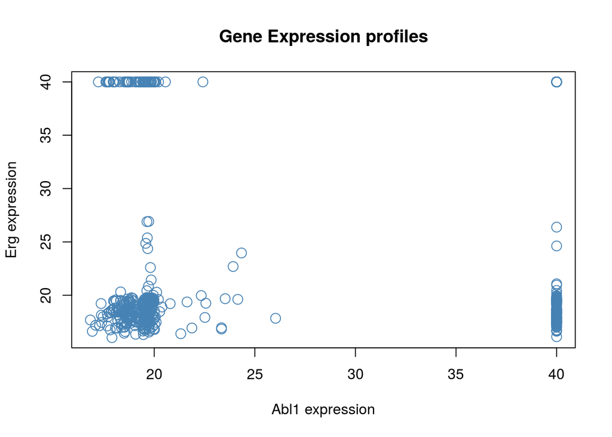

```r
with(transcripts,
     plot(Abl1, Erg,
          col ='steelblue',
          pch =21,
          cex =1.5,
          main = 'Gene Expression profiles',
          xlab = 'Abl1 expression',
          ylab = 'Erg expression'
     )
)
```

## Saving plots

The output plots can be displayed in screen or saved in many formats (jpeg, pdf, etc..). The types of outputs are known as graphical devices. Here, we give a list of image formats functions to plot in R, as you can see their names are related to image formats you are probably familiar.

- jpeg()
- png()
- pdf()
- svg()

```r
svg('heatmapMoignardPlot.svg')     ## saving to svg file format
heatmap(transcripts.m)
dev.off()                          ## closing device
```

The output plot is now redirected to the file in the current directory.

NOTE: Don’t forgive the `dev.off()` part, since this tells R that the plot is finished and hence it can save the file.

## Further references

- [Coursera Notes](http://sux13.github.io/DataScienceSpCourseNotes/4_EXDATA/Exploratory_Data_Analysis_Course_Notes.html#graphics-device). Coursera notes on Exploratory Data Analysis.